# IP_yxu17

```r
library(lpSolveAPI)
sp <- read.lp("IP_yxu17.lp")
sp
```

```
## Model name:
##             x1    x2
## Maximize     8     5
## R1           1     1  <=   6
## R2           9     5  <=  45
## Kind       Std   Std
## Type      Real  Real
## Upper      Inf   Inf
## Lower        0     0
```

### Solve

```r
solve(sp)
```

```
## [1] 0
```

```r
get.objective(sp)
```

```
## [1] 41.25
```

```r
sp
```

```
## Model name:
##             x1    x2
## Maximize     8     5
## R1           1     1  <=   6
## R2           9     5  <=  45
## Kind       Std   Std
## Type      Real  Real
## Upper      Inf   Inf
## Lower        0     0
```

```r
get.variables(sp)
```

```
## [1] 3.75 2.25
```

```r
get.constraints(sp)
```

```
## [1]  6 45
```

## R Markdown

Since we need the results yo be x1=3.75, and x2=2.25, so that we need to add more constraints to be the integer in the end.

### Branch 1

```r
sp1 <- read.lp("IP1_yxu17.lp")
sp1
```

```
## Model name:
##             x1    x2
## Maximize     8     5
## R1           1     1  <=   6
## R2           9     5  <=  45
## Kind       Std   Std
## Type      Real  Real
## Upper        3   Inf
## Lower        0     0
```

```r
solve(sp1)
```

```
## [1] 0
```

```r
get.objective(sp1)
```

```
## [1] 39
```

```r
sp1
```

```
## Model name:
##             x1    x2
## Maximize     8     5
## R1           1     1  <=   6
## R2           9     5  <=  45
## Kind       Std   Std
## Type      Real  Real
## Upper        3   Inf
## Lower        0     0
```

```r
get.variables(sp1)
```

```
## [1] 3 3
```

```r
sp1
```

```
## Model name:
##             x1    x2
## Maximize     8     5
## R1           1     1  <=   6
## R2           9     5  <=  45
## Kind       Std   Std
## Type      Real  Real
## Upper        3   Inf
## Lower        0     0
```

```r
get.constraints(sp1)
```

```
## [1]  6 42
```

### Remarks:

```r
sp2 <- read.lp("IP2_yxu17.lp")
sp2
```

```
## Model name:
##             x1    x2
## Maximize     8     5
## R1           1     1  <=   6
## R2           9     5  <=  45
## Kind       Std   Std
## Type      Real  Real
## Upper      Inf   Inf
## Lower        4     0
```

```r
solve(sp2)
```

```
## [1] 0
```

```r
get.objective(sp2)
```

```
## [1] 41
```

```r
sp2
```

```
## Model name:
##             x1    x2
## Maximize     8     5
## R1           1     1  <=   6
## R2           9     5  <=  45
## Kind       Std   Std
## Type      Real  Real
## Upper      Inf   Inf
## Lower        4     0
```

```r
get.variables(sp2)
```

```
## [1] 4.0 1.8
```

```r
sp2
```

```
## Model name:
##             x1    x2
## Maximize     8     5
## R1           1     1  <=   6
## R2           9     5  <=  45
## Kind       Std   Std
## Type      Real  Real
## Upper      Inf   Inf
## Lower        4     0
```

```r
get.constraints(sp2)
```

```
## [1]  5.8 45.0
```

### Remarks:

From above, we could gect the branch 2(4,1.8,41), it means the x1=4,x2=1.8 and the Max=41.

### Branch 3

```r
sp3 <- read.lp("IP3_yxu17.lp")
sp3
```

```
## Model name:
##             x1    x2
## Maximize     8     5
## R1           1     1  <=   6
## R2           9     5  <=  45
## Kind       Std   Std
## Type      Real  Real
## Upper      Inf     1
## Lower        4     0
```

```r
solve(sp3)
```

```
## [1] 0
```

```r
get.objective(sp3)
```

```
## [1] 40.55556
```

```r
sp3
```

```
## Model name:
##             x1    x2
## Maximize     8     5
## R1           1     1  <=   6
## R2           9     5  <=  45
## Kind       Std   Std
## Type      Real  Real
## Upper      Inf     1
## Lower        4     0
```

```r
get.variables(sp3)
```

```
## [1] 4.444444 1.000000
```

```r
sp3
```

```
## Model name:
##             x1    x2
## Maximize     8     5
## R1           1     1  <=   6
## R2           9     5  <=  45
## Kind       Std   Std
## Type      Real  Real
## Upper      Inf     1
## Lower        4     0
```

```r
get.constraints(sp3)
```

```
## [1]  5.444444 45.000000
```

```r
sp3
```

```
## Model name:
##             x1    x2
## Maximize     8     5
## R1           1     1  <=   6
## R2           9     5  <=  45
## Kind       Std   Std
## Type      Real  Real
## Upper      Inf     1
## Lower        4     0
```

### Remarks:

From above, we could gect the branch 3(4.444444,1,55556).

### Branch 4

```r
sp4 <- read.lp("IP4_yxu17.lp")
sp4
```

```
## Model name:
##             x1    x2
## Maximize     8     5
## R1           1     1  <=   6
## R2           9     5  <=  45
## Kind       Std   Std
## Type      Real  Real
## Upper        4     1
## Lower        4     0
```

```r
solve(sp4)
```

```
## [1] 0
```

```r
get.objective(sp4)
```

```
## [1] 37
```

```r
sp4
```

```
## Model name:
##             x1    x2
## Maximize     8     5
## R1           1     1  <=   6
## R2           9     5  <=  45
## Kind       Std   Std
## Type      Real  Real
## Upper        4     1
## Lower        4     0
```

```r
get.variables(sp4)
```

```
## [1] 4 1
```

```r
sp4
```

```
## Model name:
##             x1    x2
## Maximize     8     5
## R1           1     1  <=   6
## R2           9     5  <=  45
## Kind       Std   Std
## Type      Real  Real
## Upper        4     1
## Lower        4     0
```

```r
get.constraints(sp4)
```

```
## [1]  5 41
```

```r
sp4
```

```
## Model name:
##             x1    x2
## Maximize     8     5
## R1           1     1  <=   6
## R2           9     5  <=  45
## Kind       Std   Std
## Type      Real  Real
## Upper        4     1
## Lower        4     0
```

### Remarks:

From above, we could gect the branch 4(4,1,37).

#### Branch 5

```r
sp5 <- read.lp("IP5_yxu17.lp")
sp5
```

```
## Model name:
##             x1    x2
## Maximize     8     5
## R1           1     1  <=   6
## R2           9     5  <=  45
## Kind       Std   Std
## Type      Real  Real
## Upper      Inf     1
## Lower        5     0
```

```r
solve(sp5)
```

```
## [1] 0
```

```r
get.objective(sp5)
```

```
## [1] 40
```

```r
sp5
```

```
## Model name:
##             x1    x2
## Maximize     8     5
## R1           1     1  <=   6
## R2           9     5  <=  45
## Kind       Std   Std
## Type      Real  Real
## Upper      Inf     1
## Lower        5     0
```

```r
get.variables(sp5)
```

```
## [1] 5 0
```

```r
sp5
```

```
## Model name:
##             x1    x2
## Maximize     8     5
## R1           1     1  <=   6
## R2           9     5  <=  45
## Kind       Std   Std
## Type      Real  Real
## Upper      Inf     1
## Lower        5     0
```

```r
get.constraints(sp5)
```

```
## [1]  5 45
```

```r
sp5
```

```
## Model name:
##             x1    x2
## Maximize     8     5
## R1           1     1  <=   6
## R2           9     5  <=  45
## Kind       Std   Std
## Type      Real  Real
## Upper      Inf     1
## Lower        5     0
```

### Remarks

From above, we could gect the branch 5(5,0,40).

### Branch 6

```r
sp6 <- read.lp("IP6_yxu17.lp")
sp6
```

```
## Model name:
##             x1    x2
## Maximize     8     5
## R1           1     1  <=   6
## R2           9     5  <=  45
## Kind       Std   Std
## Type      Real  Real
## Upper      Inf   Inf
## Lower        4     2
```

```r
solve(sp6)
```

```
## [1] 2
```

```r
get.objective(sp6)
```

```
## [1] -1e+30
```

```r
sp6
```

```
## Model name:
##             x1    x2
## Maximize     8     5
## R1           1     1  <=   6
## R2           9     5  <=  45
## Kind       Std   Std
## Type      Real  Real
## Upper      Inf   Inf
## Lower        4     2
```

```r
get.variables(sp6)
```

```
## [1] 0 0
```

```r
sp6
```

```
## Model name:
##             x1    x2
## Maximize     8     5
## R1           1     1  <=   6
## R2           9     5  <=  45
## Kind       Std   Std
## Type      Real  Real
## Upper      Inf   Inf
## Lower        4     2
```

```r
get.constraints(sp6)
```

```
## [1] 1.290740e-231 6.938032e-310
```

```r
sp6
```

```
## Model name:
##             x1    x2
## Maximize     8     5
## R1           1     1  <=   6
## R2           9     5  <=  45
## Kind       Std   Std
## Type      Real  Real
## Upper      Inf   Inf
## Lower        4     2
```

### Remarks:

No solution for this branch

### Branch 7

```r
sp7 <- read.lp("IP7_yxu17.lp")
sp7
```

```
## Model name:
##             x1    x2
## Maximize     8     5
## R1           1     1  <=   6
## R2           9     5  <=  45
## Kind       Std   Std
## Type      Real  Real
## Upper      Inf     7
## Lower        0     0
```

```r
solve(sp7)
```

```
## [1] 0
```

```r
get.objective(sp7)
```

```
## [1] 41.25
```

```r
sp7
```

```
## Model name:
##             x1    x2
## Maximize     8     5
## R1           1     1  <=   6
## R2           9     5  <=  45
## Kind       Std   Std
## Type      Real  Real
## Upper      Inf     7
## Lower        0     0
```

```r
get.variables(sp7)
```

```
## [1] 3.75 2.25
```

```r
sp7
```

```
## Model name:
##             x1    x2
## Maximize     8     5
## R1           1     1  <=   6
## R2           9     5  <=  45
## Kind       Std   Std
## Type      Real  Real
## Upper      Inf     7
## Lower        0     0
```

```r
get.constraints(sp7)
```

```
## [1]  6 45
```

```r
sp7
```

```
## Model name:
##             x1    x2
## Maximize     8     5
## R1           1     1  <=   6
## R2           9     5  <=  45
## Kind       Std   Std
## Type      Real  Real
## Upper      Inf     7
## Lower        0     0
```

### Remarks

#### Branch 8

```r
sp8 <- read.lp("IP8_yxu17.lp")
sp8
```

```
## Model name:
##             x1    x2
## Maximize     8     5
## R1           1     1  <=   6
## R2           9     5  <=  45
## Kind       Std   Std
## Type      Real  Real
## Upper        3     2
## Lower        0     0
```

```r
solve(sp8)
```

```
## [1] 0
```

```r
get.objective(sp8)
```

```
## [1] 34
```

```r
sp8
```

```
## Model name:
##             x1    x2
## Maximize     8     5
## R1           1     1  <=   6
## R2           9     5  <=  45
## Kind       Std   Std
## Type      Real  Real
## Upper        3     2
## Lower        0     0
```

```r
get.variables(sp8)
```

```
## [1] 3 2
```

```r
sp8
```

```
## Model name:
##             x1    x2
## Maximize     8     5
## R1           1     1  <=   6
## R2           9     5  <=  45
## Kind       Std   Std
## Type      Real  Real
## Upper        3     2
## Lower        0     0
```

```r
get.constraints(sp8)
```

```
## [1]  5 37
```

```r
sp8
```

```
## Model name:
##             x1    x2
## Maximize     8     5
## R1           1     1  <=   6
## R2           9     5  <=  45
## Kind       Std   Std
## Type      Real  Real
## Upper        3     2
## Lower        0     0
```

### Remarks

From above, we could gect the branch 8 (3,2,34).

```r
sp9 <- read.lp("IP9_yxu17.lp")
sp9
```

```
## Model name:
##             x1    x2
## Maximize     8     5
## R1           1     1  <=   6
## R2           9     5  <=  45
## Kind       Std   Std
## Type      Real  Real
## Upper      Inf     2
## Lower        4     0
```

```r
solve(sp9)
```

```
## [1] 0
```

```r
get.objective(sp9)
```

```
## [1] 41
```

```r
sp9
```

```
## Model name:
##             x1    x2
## Maximize     8     5
## R1           1     1  <=   6
## R2           9     5  <=  45
## Kind       Std   Std
## Type      Real  Real
## Upper      Inf     2
## Lower        4     0
```

```r
get.variables(sp9)
```

```
## [1] 4.0 1.8
```

```r
sp9
```

```
## Model name:
##             x1    x2
## Maximize     8     5
## R1           1     1  <=   6
## R2           9     5  <=  45
## Kind       Std   Std
## Type      Real  Real
## Upper      Inf     2
## Lower        4     0
```

```r
get.constraints(sp9)
```

```
## [1]  5.8 45.0
```

```r
sp9
```

```
## Model name:
##             x1    x2
## Maximize     8     5
## R1           1     1  <=   6
## R2           9     5  <=  45
## Kind       Std   Std
## Type      Real  Real
## Upper      Inf     2
## Lower        4     0
```

### Remarks

From above, we could gect the branch 9 (4.0,1.8,41).

### Branch 10

```r
sp10 <- read.lp("IP10_yxu17.lp")
sp10
```

```
## Model name:
##             x1    x2
## Maximize     8     5
## R1           1     1  <=   6
## R2           9     5  <=  45
## Kind       Std   Std
## Type      Real  Real
## Upper      Inf     2
## Lower        4     0
```

```r
solve(sp10)
```

```
## [1] 0
```

```r
get.objective(sp10)
```

```
## [1] 41
```

```r
sp10
```

```
## Model name:
##             x1    x2
## Maximize     8     5
## R1           1     1  <=   6
## R2           9     5  <=  45
## Kind       Std   Std
## Type      Real  Real
## Upper      Inf     2
## Lower        4     0
```

```r
get.variables(sp10)
```

```
## [1] 4.0 1.8
```

```r
sp10
```

```
## Model name:
##             x1    x2
## Maximize     8     5
## R1           1     1  <=   6
## R2           9     5  <=  45
## Kind       Std   Std
## Type      Real  Real
## Upper      Inf     2
## Lower        4     0
```

```r
get.constraints(sp10)
```

```
## [1]  5.8 45.0
```

```r
sp10
```

```
## Model name:
##             x1    x2
## Maximize     8     5
## R1           1     1  <=   6
## R2           9     5  <=  45
## Kind       Std   Std
## Type      Real  Real
## Upper      Inf     2
## Lower        4     0
```

### Remarks

#### Branch 11

```r
sp11 <- read.lp("IP11_yxu17.lp")
sp11
```

```
## Model name:
##             x1    x2
## Maximize     8     5
## R1           1     1  <=   6
## R2           9     5  <=  45
## Kind       Std   Std
## Type      Real  Real
## Upper        4     1
## Lower        4     0
```

```r
solve(sp11)
```

```
## [1] 0
```

```r
get.objective(sp11)
```

```
## [1] 37
```

```r
sp11
```

```
## Model name:
##             x1    x2
## Maximize     8     5
## R1           1     1  <=   6
## R2           9     5  <=  45
## Kind       Std   Std
## Type      Real  Real
## Upper        4     1
## Lower        4     0
```

```r
get.variables(sp11)
```

```
## [1] 4 1
```

```r
sp11
```

```
## Model name:
##             x1    x2
## Maximize     8     5
## R1           1     1  <=   6
## R2           9     5  <=  45
## Kind       Std   Std
## Type      Real  Real
## Upper        4     1
## Lower        4     0
```

```r
get.constraints(sp11)
```

```
## [1]  5 41
```

```r
sp11
```

```
## Model name:
##             x1    x2
## Maximize     8     5
## R1           1     1  <=   6
## R2           9     5  <=  45
## Kind       Std   Std
## Type      Real  Real
## Upper        4     1
## Lower        4     0
```

### Remarks:

From above, we could gect the branch 11 (4,1,37).

#### Branch 12

```r
sp12 <- read.lp("IP12_yxu17.lp")
sp12
```

```
## Model name:
##             x1    x2
## Maximize     8     5
## R1           1     1  <=   6
## R2           9     5  <=  45
## Kind       Std   Std
## Type      Real  Real
## Upper      Inf     1
## Lower        5     0
```

```r
solve(sp12)
```

```
## [1] 0
```

```r
get.objective(sp12)
```

```
## [1] 40
```

```r
sp12
```

```
## Model name:
##             x1    x2
## Maximize     8     5
## R1           1     1  <=   6
## R2           9     5  <=  45
## Kind       Std   Std
## Type      Real  Real
## Upper      Inf     1
## Lower        5     0
```

```r
get.variables(sp12)
```

```
## [1] 5 0
```

```r
sp12
```

```
## Model name:
##             x1    x2
## Maximize     8     5
## R1           1     1  <=   6
## R2           9     5  <=  45
## Kind       Std   Std
## Type      Real  Real
## Upper      Inf     1
## Lower        5     0
```

```r
get.constraints(sp12)
```

```
## [1]  5 45
```

```r
sp12
```

```
## Model name:
##             x1    x2
## Maximize     8     5
## R1           1     1  <=   6
## R2           9     5  <=  45
## Kind       Std   Std
## Type      Real  Real
## Upper      Inf     1
## Lower        5     0
```

### Branch 13

```r
sp13 <- read.lp("IP13_yxu17.lp")
sp13
```

```
## Model name:
##             x1    x2
## Maximize     8     5
## R1           1     1  <=   6
## R2           9     5  <=  45
## Kind       Std   Std
## Type      Real  Real
## Upper      Inf     2
## Lower        4     2
```

```r
solve(sp13)
```

```
## [1] 2
```

```r
get.objective(sp13)
```

```
## [1] -1e+30
```

```r
sp13
```

```
## Model name:
##             x1    x2
## Maximize     8     5
## R1           1     1  <=   6
## R2           9     5  <=  45
## Kind       Std   Std
## Type      Real  Real
## Upper      Inf     2
## Lower        4     2
```

```r
get.variables(sp13)
```

```
## [1] 0 0
```

```r
sp13
```

```
## Model name:
##             x1    x2
## Maximize     8     5
## R1           1     1  <=   6
## R2           9     5  <=  45
## Kind       Std   Std
## Type      Real  Real
## Upper      Inf     2
## Lower        4     2
```

```r
get.constraints(sp13)
```

```
## [1] 0 0
```

```r
sp13
```

```
## Model name:
##             x1    x2
## Maximize     8     5
## R1           1     1  <=   6
## R2           9     5  <=  45
## Kind       Std   Std
## Type      Real  Real
## Upper      Inf     2
## Lower        4     2
```

### Remarks:

No solution for this branch

## Branch 14

```r
sp14 <- read.lp("IP14_yxu17.lp")
sp14
```

```
## Model name:
##             x1    x2
## Maximize     8     5
## R1           1     1  <=   6
## R2           9     5  <=  45
## Kind       Std   Std
## Type      Real  Real
## Upper      Inf   Inf
## Lower        0     3
```

```r
solve(sp14)
```

```
## [1] 0
```

```r
get.objective(sp14)
```

```
## [1] 39
```

```r
sp14
```

```
## Model name:
##             x1    x2
## Maximize     8     5
## R1           1     1  <=   6
## R2           9     5  <=  45
## Kind       Std   Std
## Type      Real  Real
## Upper      Inf   Inf
## Lower        0     3
```

```r
get.variables(sp14)
```

```
## [1] 3 3
```

```r
sp14
```

```
## Model name:
##             x1    x2
## Maximize     8     5
## R1           1     1  <=   6
## R2           9     5  <=  45
## Kind       Std   Std
## Type      Real  Real
## Upper      Inf   Inf
## Lower        0     3
```

```r
get.constraints(sp14)
```

```
## [1]  6 42
```

```r
sp14
```

```
## Model name:
##             x1    x2
## Maximize     8     5
## R1           1     1  <=   6
## R2           9     5  <=  45
## Kind       Std   Std
## Type      Real  Real
## Upper      Inf   Inf
## Lower        0     3
```

### Remarks:

#### Remarks

Put all variabels into a csv files.

```r
IPcsv <- read.csv("IP_yxu17.csv")
print(IPcsv)
```

```
##    Branch.ID       X1   X2 Obejctive
## 1          0 3.750000 2.25  41.25000
## 2          1 3.000000 3.00  39.00000
## 3          2 4.000000 1.80  41.00000
## 4          3 4.444444 1.00  40.55556
## 5          4 4.000000 1.00  37.00000
## 6          5 5.000000 0.00  40.00000
## 7          6       NA   NA        NA
## 8          7 3.888889 2.00  41.11111
## 9          8 3.000000 2.00  34.00000
## 10         9 4.000000 1.80  41.00000
## 11        10 4.444444 1.00  40.55556
## 12        11 4.000000 1.00  37.00000
## 13        12 5.000000 0.00  40.00000
## 14        13       NA   NA        NA
## 15        14 3.000000 3.00  39.00000
```

```r
summary(IPcsv)
```

```
##    Branch.ID          X1              X2          Obejctive
##  Min.   : 0.0   Min.   :3.000   Min.   :0.000   Min.   :34.00
##  1st Qu.: 3.5   1st Qu.:3.750   1st Qu.:1.000   1st Qu.:39.00
##  Median : 7.0   Median :4.000   Median :1.800   Median :40.00
##  Mean   : 7.0   Mean   :3.964   Mean   :1.527   Mean   :39.34
##  3rd Qu.:10.5   3rd Qu.:4.444   3rd Qu.:2.000   3rd Qu.:41.00
##  Max.   :14.0   Max.   :5.000   Max.   :3.000   Max.   :41.25
##                 NA's   :2       NA's   :2       NA's   :2
```

```r
library(ggplot2)
library(esquisse)
library(shiny)
```

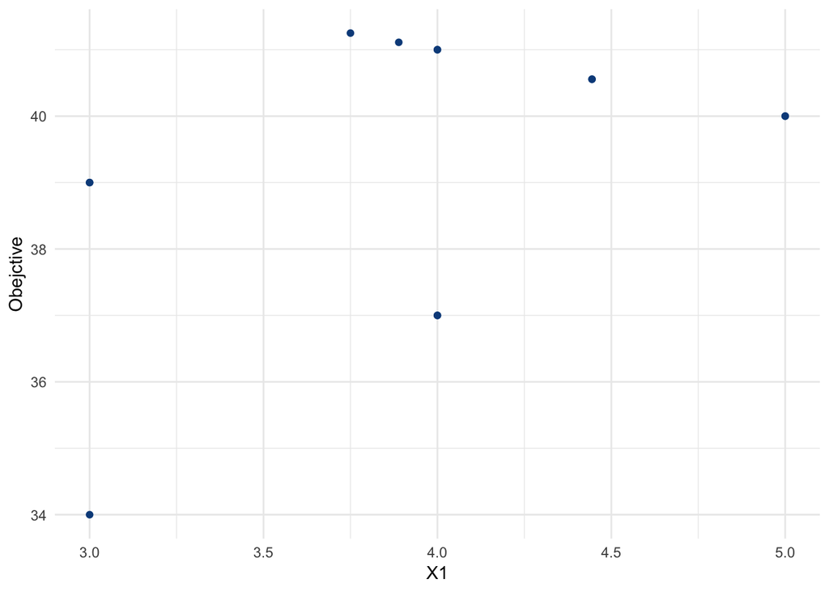

```r
ggplot(data = IPcsv) +
  aes(x = X1, y = Obejctive) +
  geom_point(color = '#0c4c8a') +
  theme_minimal()
```